# Week 9 - Lecture Notes

Author

Linnea Nordli

Published

October 20, 2026

# Working with Factors

## Load libraries

```r
library(tidyverse)
library(here)
library(dplyr)
```

## Import data

```r
income_mean <- read_csv("https://raw.githubusercontent.com/rfordatascience/tidytuesday/master/data/2021/2021-02-09/income_mean.csv")
```

## What is a factor?

A factor is a specialized version of a character — it is how R truly stores categorical data.

- The values a factor can take are called levels
- Levels let you control the order of categories in plots and summaries
- The default order of levels is always alphabetical
- Under the hood, R stores factors as integers (1, 2, 3…) mapped to level labels

```r
fruits <- factor(c("Apple", "Grape", "Banana"))
fruits
```

```
[1] Apple  Grape  Banana
Levels: Apple Banana Grape
```

## Factor Booby-Traps

Imagine a column of numbers that has a single typo — R reads the whole thing as characters. If you then convert to numeric, real text becomes NA:

```r
test <- c("A", "1", "2")
as.numeric(test)
```

```
[1] NA  1  2
```

Now try converting after converting to a factor first — this is even worse:

```r
test <- factor(test)
as.numeric(test)    # returns the underlying integer codes, not the original values!
```

```
[1] 3 1 2
```

### Read in data safely

Factor booby-traps are why there was a push to stop importing strings as factors automatically. Always use read_csv() from {readr}. You then convert to factors intentionally and explicitly, only when you need a specific ordering — not by accident on import.

- read.csv() — base R
  - Strings become factors automatically
- read_csv() — tidyverse
  - Strings stay as characters

# The {forcats} Package

**For cat**egorical data — also an anagram of “factors”. All main functions start with **fct_**

### StarWars data

```r
glimpse(starwars)
```

```
Rows: 87
Columns: 14
$ name       <chr> "Luke Skywalker", "C-3PO", "R2-D2", "Darth Vader", "Leia Or…
$ height     <int> 172, 167, 96, 202, 150, 178, 165, 97, 183, 182, 188, 180, 2…
$ mass       <dbl> 77.0, 75.0, 32.0, 136.0, 49.0, 120.0, 75.0, 32.0, 84.0, 77.…
$ hair_color <chr> "blond", NA, NA, "none", "brown", "brown, grey", "brown", N…
$ skin_color <chr> "fair", "gold", "white, blue", "white", "light", "light", "…
$ eye_color  <chr> "blue", "yellow", "red", "yellow", "brown", "blue", "blue",…
$ birth_year <dbl> 19.0, 112.0, 33.0, 41.9, 19.0, 52.0, 47.0, NA, 24.0, 57.0, …
$ sex        <chr> "male", "none", "none", "male", "female", "male", "female",…
$ gender     <chr> "masculine", "masculine", "masculine", "masculine", "femini…
$ homeworld  <chr> "Tatooine", "Tatooine", "Naboo", "Tatooine", "Alderaan", "T…
$ species    <chr> "Human", "Droid", "Droid", "Human", "Human", "Human", "Huma…
$ films      <list> <"A New Hope", "The Empire Strikes Back", "Return of the J…
$ vehicles   <list> <"Snowspeeder", "Imperial Speeder Bike">, <>, <>, <>, "Imp…
$ starships  <list> <"X-wing", "Imperial shuttle">, <>, <>, "TIE Advanced x1",…
```

How many of each species?

```r
starwars |>
  filter(!is.na(species)) |>   # remove NAs
  count(species, sort = TRUE)
```

```
# A tibble: 37 × 2
   species      n
   <chr>    <int>
 1 Human       35
 2 Droid        6
 3 Gungan       3
 4 Kaminoan     2
 5 Mirialan     2
 6 Twi'lek      2
 7 Wookiee      2
 8 Zabrak       2
 9 Aleena       1
10 Besalisk     1
# ℹ 27 more rows
```

## fct_lump() — Lump Rare Levels Together

```r
star_counts <- starwars |>
  filter(!is.na(species)) |>
  mutate(species = fct_lump(species, n = 3)) |>
  count(species)

star_counts
```

```
# A tibble: 4 × 2
  species     n
  <fct>   <int>
1 Droid       6
2 Gungan      3
3 Human      35
4 Other      39
```

## Reordering Factors

The default alphabetical order is almost never what you want in a plot. Start with a basic Bar Plot.

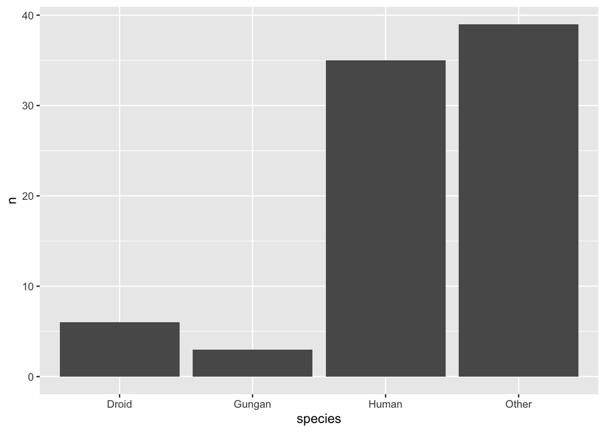

```r
star_counts |>
  ggplot(aes(x = species, y = n)) +
  geom_col()
```

This is hard to read. It would be more useful sorted by count.

### fct_reorder() — Sort by Another Variable

**fct_reorder(f, x)** reorders the levels of factor f by the values of x:

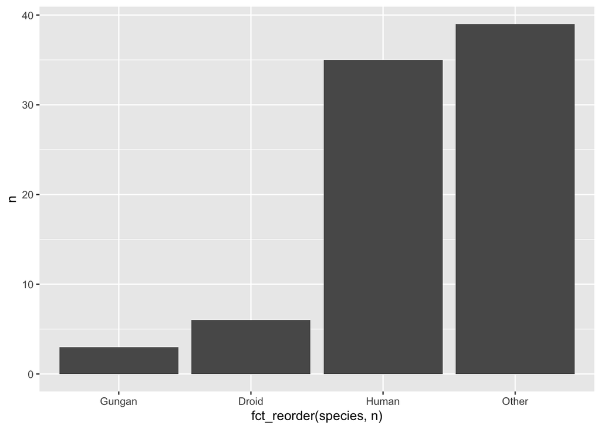

```r
star_counts |>
  ggplot(aes(x = fct_reorder(species, n), y = n)) +
  geom_col()
```

### fct_reorder() — Descending Order

Add **.desc = TRUE** to flip the order:

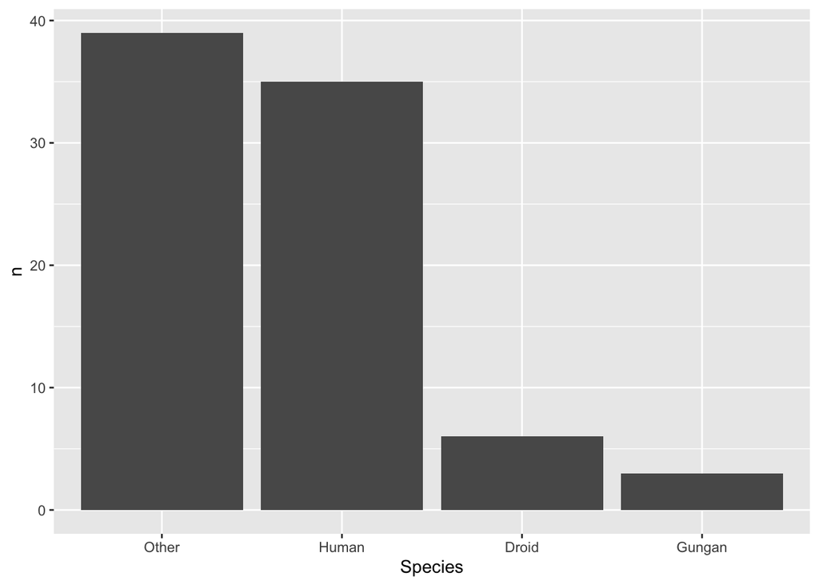

```r
star_counts |>
  ggplot(aes(x = fct_reorder(species, n, .desc = TRUE), y = n)) +
  geom_col() +
  labs(x = "Species")
```

## Reordering Line Plot Legends

The income_mean Data

```r
glimpse(income_mean)
```

```
Rows: 3,708
Columns: 5
$ year            <dbl> 2019, 2019, 2019, 2019, 2019, 2019, 2018, 2018, 2018, …
$ race            <chr> "All Races", "All Races", "All Races", "All Races", "A…
$ dollar_type     <chr> "Current Dollars", "Current Dollars", "Current Dollars…
$ income_quintile <chr> "Lowest", "Second", "Middle", "Fourth", "Highest", "To…
$ income_dollars  <dbl> 15286, 40652, 68938, 111112, 254449, 451122, 13775, 37…
```

### Summarize by Year and Quintile

```r
total_income <- income_mean |>
  group_by(year, income_quintile) |>
  summarise(income_dollars_sum = sum(income_dollars), .groups = "drop") |>
  mutate(income_quintile = factor(income_quintile)) # converts the character column to a factor so we can reorder it
```

**mutate(income_quintile = factor(income_quintile))** converts the character column to a factor so we can reorder it. If you skip this step, **{forcats}** reordering functions won’t work.

### Basic Line Plot — Legend in Wrong Order

The legend order doesn’t match the line order — the highest income group is at the bottom of the legend.

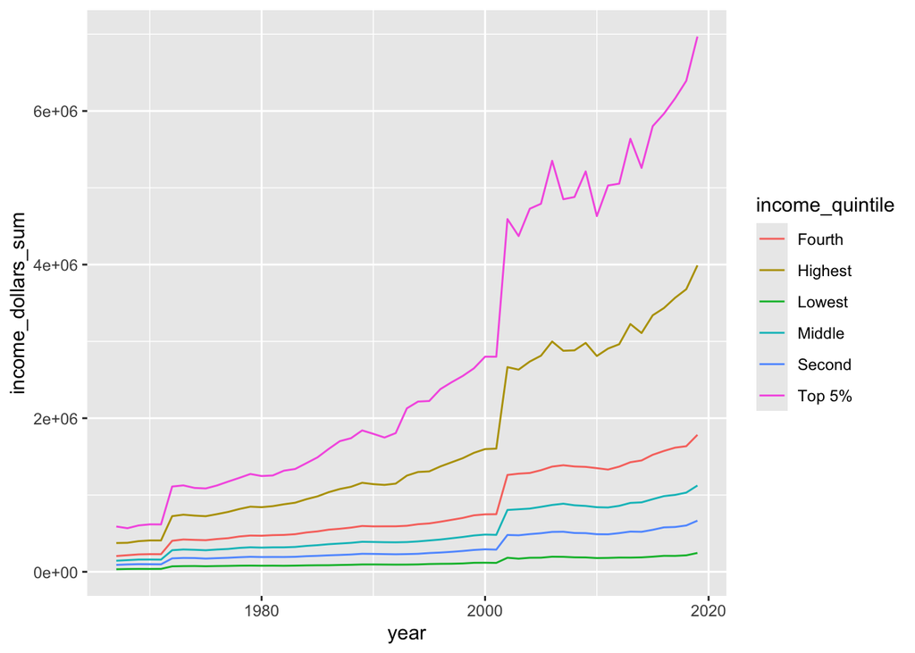

```r
total_income |>
  ggplot(aes(x = year, y = income_dollars_sum,
             color = income_quintile)) +
  geom_line()
```

### fct_reorder2() — Reorder by Two Variables

fct_reorder2(f, x, y) reorders f by the values of y at the largest values of x. This aligns the legend with the right end of the lines:

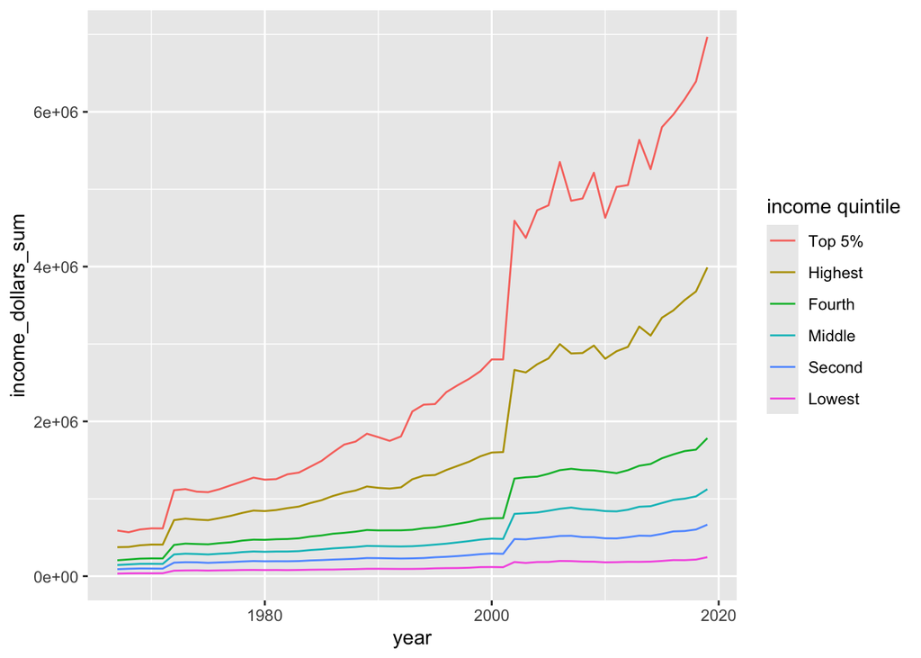

```r
total_income |>
  ggplot(aes(x = year, y = income_dollars_sum,
             color = fct_reorder2(income_quintile, year, income_dollars_sum))) + # reorder
  geom_line() +
  labs(color = "income quintile")
```

## Setting Levels Manually

Sometimes you need a specific order that isn’t determined by the data.

### factor() with levels = …

Use the **levels** argument inside **factor()** to set the exact order you want. This is especially useful for months, tide heights, treatment levels — any categorical variable with a meaningful inherent order that isn’t alphabetical.

#### Without levels — alphabetical by default

```r
# Without levels — alphabetical by default
x1 <- factor(c("Jan", "Mar", "Apr", "Dec"))
x1
```

```
[1] Jan Mar Apr Dec
Levels: Apr Dec Jan Mar
```

#### With levels — your specified order

```r
x1 <- factor(c("Jan", "Mar", "Apr", "Dec"),
             levels = c("Jan", "Mar", "Apr", "Dec"))
x1
```

```
[1] Jan Mar Apr Dec
Levels: Jan Mar Apr Dec
```

## Subsetting Factors

What happens to factor levels when you filter your data?

### Filter to Common Species

Let’s filter the starwars data to only species with more than 3 individuals:

```r
starwars_clean <- starwars |>
  filter(!is.na(species)) |>
  count(species, sort = TRUE) |>
  mutate(species = factor(species)) |>   # convert to factor
  filter(n > 3)                          # keep only common species

starwars_clean
```

```
# A tibble: 2 × 2
  species     n
  <fct>   <int>
1 Human      35
2 Droid       6
```

Check the factor levels

```r
levels(starwars_clean$species)   # check the factor levels
```

```
 [1] "Aleena"         "Besalisk"       "Cerean"         "Chagrian"
 [5] "Clawdite"       "Droid"          "Dug"            "Ewok"
 [9] "Geonosian"      "Gungan"         "Human"          "Hutt"
[13] "Iktotchi"       "Kaleesh"        "Kaminoan"       "Kel Dor"
[17] "Mirialan"       "Mon Calamari"   "Muun"           "Nautolan"
[21] "Neimodian"      "Pau'an"         "Quermian"       "Rodian"
[25] "Skakoan"        "Sullustan"      "Tholothian"     "Togruta"
[29] "Toong"          "Toydarian"      "Trandoshan"     "Twi'lek"
[33] "Vulptereen"     "Wookiee"        "Xexto"          "Yoda's species"
[37] "Zabrak"
```

### droplevels() — Remove Unused Levels

**droplevels() (base R)** or **fct_drop() (forcats)** removes any levels that no longer appear in the data:

```r
starwars_clean <- starwars |>
  filter(!is.na(species)) |>
  count(species, sort = TRUE) |>
  mutate(species = factor(species)) |>
  filter(n > 3) |>
  droplevels()                           # remove unused levels
```

Check factor levels

```r
levels(starwars_clean$species)
```

```
[1] "Droid" "Human"
```

### fct_recode() — Rename Levels

**fct_recode(f, “new name” = “old name”)** renames one or more levels:

```r
starwars_clean <- starwars |>
  filter(!is.na(species)) |>
  count(species, sort = TRUE) |>
  mutate(species = factor(species)) |>
  filter(n > 3) |>
  droplevels() |>
  mutate(species = fct_recode(species, "Humanoid" = "Human")) # renames

starwars_clean
```

```
# A tibble: 2 × 2
  species      n
  <fct>    <int>
1 Humanoid    35
2 Droid        6
```

## Other Helpful **{forcats}** Functions

| **Function** | **What it does** |
| --- | --- |
| fct_relevel() | Move specific levels to the front |
| fct_rev() | Reverse the order of levels |
| fct_collapse() | Collapse multiple levels into one |
| fct_na_value_to_level() | Convert NA into an explicit level |
| fct_infreq() | Order levels by frequency |